# Lab2

Eliott Doyle, Diana DeWald

1/24/2022

# 1. Start with the google trends data

### >> Visualize the change in trends for each hurricane over time in one plot with three scales. Map color to a discrete scale.

[figure not shown]

#### The three scales for our plot are: google search frequency on y-axis (we assume that the values in the dataset were thousands), date on the x-axis, and hurricane on a color scale.

### >> Visualize the trends again, this time with solid shapes (if your first plot was already solid shapes, use lines). Hint, geom_area can be difficult to work with if you have a grouping factor. Try geom_ribbon instead.

[figure not shown]

#### The scales used for the second plot are similar to the first: google search frequency on y-axis, date on the x-axis, but now hurricane is scaled via shapes.

### >> Visualize the same relation, but change the scales so color is mapped to a continuous scale (the other scales should be discrete).

[figure not shown]

#### For the third plot, date remains on the x-axis, but now we’ve put hurricane on the y-axis and mapped the number of google searches (continuous) to a color scale using the heatmap function geom_tile.

### >> Create a data frame (using tibble() or data.frame()) that includes the dates that each hurricane made landfall. Annotate one of your first two plots to include these reference points with vertical lines (Hint: use geom_vline(), specifying the data source for this layer as this new dataset). You do not have to include text annotations - just the vertical lines, but if you would like to try, look into geom_text() or geom_label(). The hurricanes made landfall on (approximately) the following days:

- Harvey: August 25, 2017
- Irma: September 10, 2017
- Jose: Did not make landfall
- Maria: September 20, 2017

[figure not shown]

### >> Make any final modifications to the plot you’d like to communicate the information as effectively as possible

[figure not shown]

# 2. Replicate the “National cable news networks” plot from the story using the tv_states data. Don’t worry about all the labels. Try to match the colors but don’t worry about getting them exact.

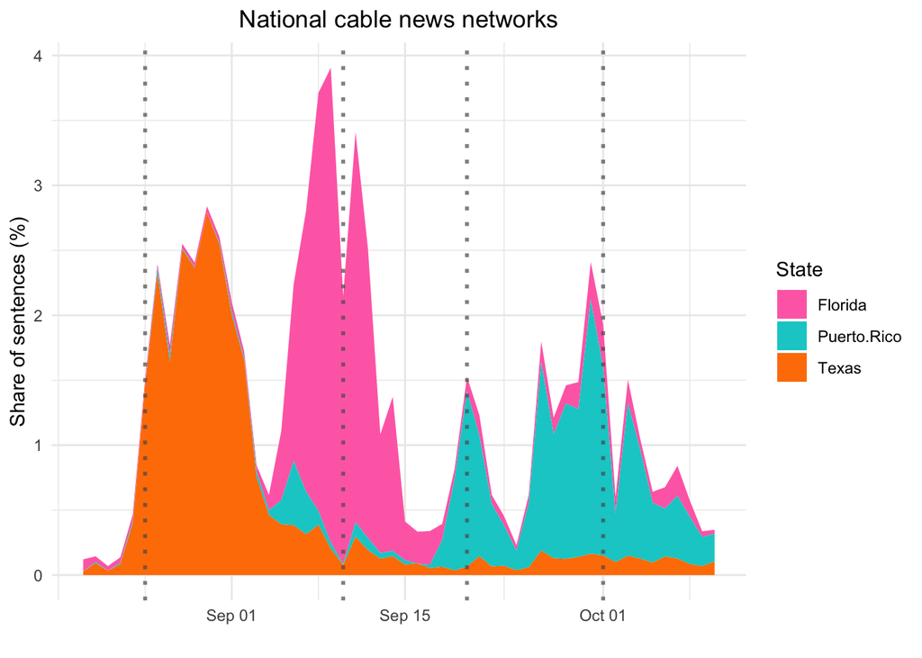

# 3. Use the comic_characters dataset to visualize the proportion of different genders using at least three different methods. With your final visualization, make any additional modifications you think would help reduce the cognitive load necessary to comprehend the figure.

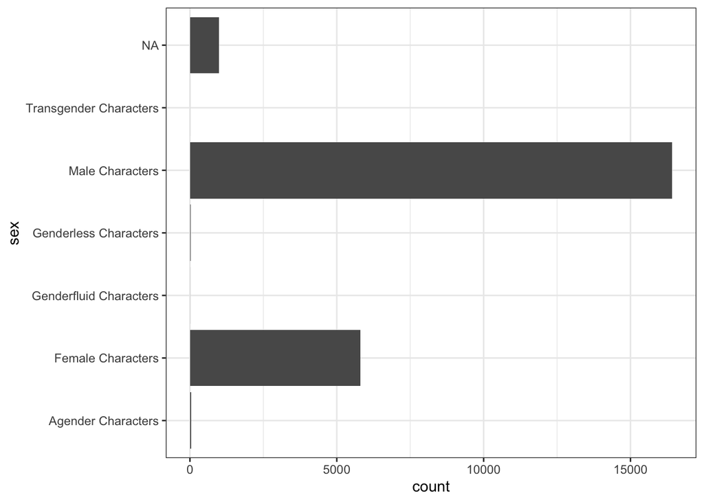

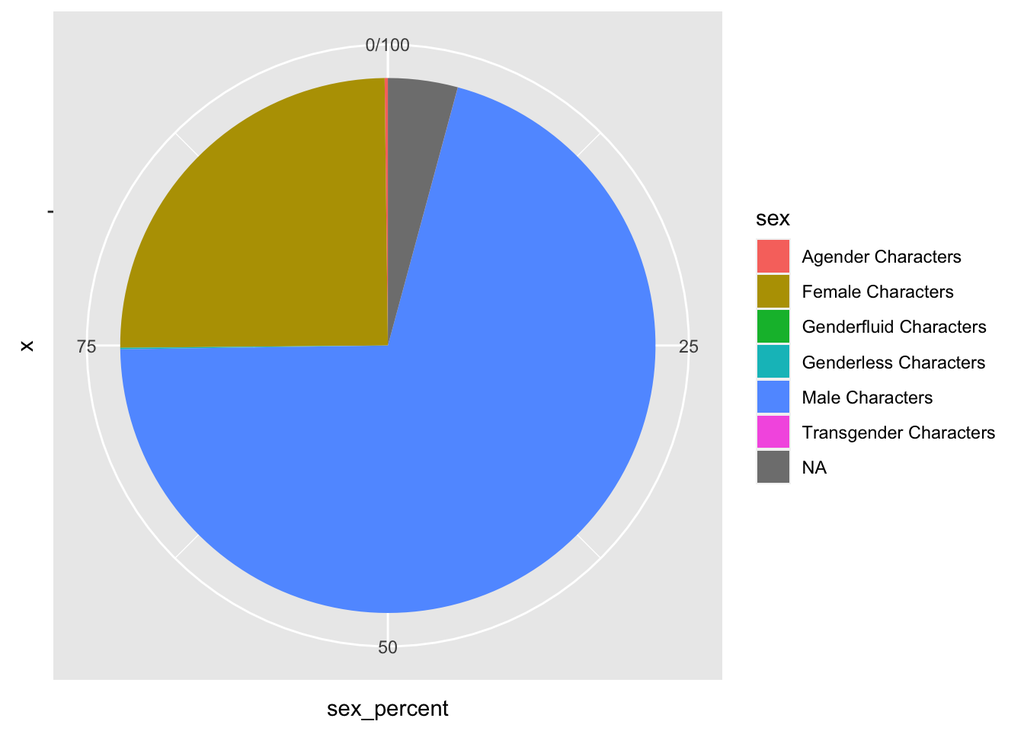

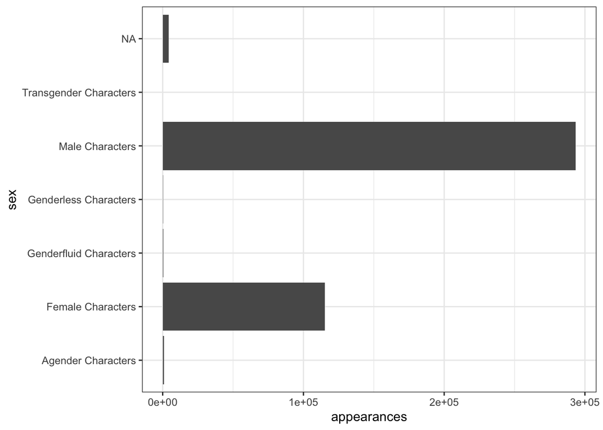

#### The three charts are number of characters by sex in bar chart form, percentage of characters by sex in pie chart form, and number of appearances by character sex. I like the first one, so I will clean that one up.

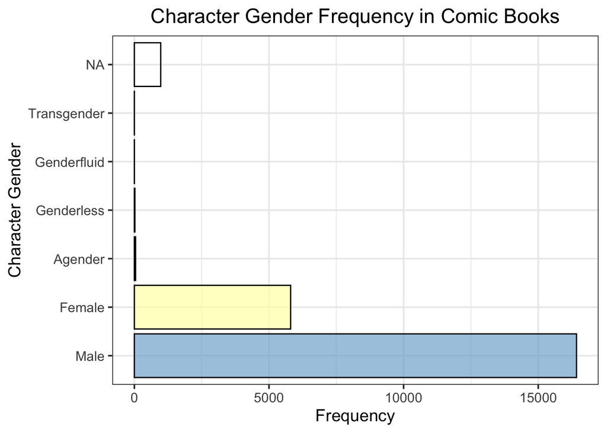